# Analysis of variance

Lieven Clement

statOmics, Ghent University (https://statomics.github.io)

# 1 Prostacyclin Example

Researchers study the effect of arachidonic acid on prostacyclin level in blood plasma. They use 3 different concentrations of arachidonic acid:

- low,
- medium and
- high dose

Each treatment is adopted to 12 rats. They measure the prostacyclin levels in blood plasma using an ELOSA fluorescence measurement.

```r
prostacyclin <- read_tsv("https://raw.githubusercontent.com/GTPB/PSLS20/master/data/prostacyclin.txt")
```

```r
head(prostacyclin)
```

```
# A tibble: 6 x 2
  prostac  dose
    <dbl> <dbl>
1    19.2    10
2    10.8    10
3    33.6    10
4    11.9    10
5    15.9    10
6    33.3    10
```

```r
prostacyclin <- prostacyclin %>%
  mutate(dose = as.factor(dose))
```

## 1.1 Data exploration

We assess if distribution of the prostacyclin concentration for each of the arachidonic acid treatments using a boxplot. We also assess if the data are normally distributed in each treatment group using QQ-plots.

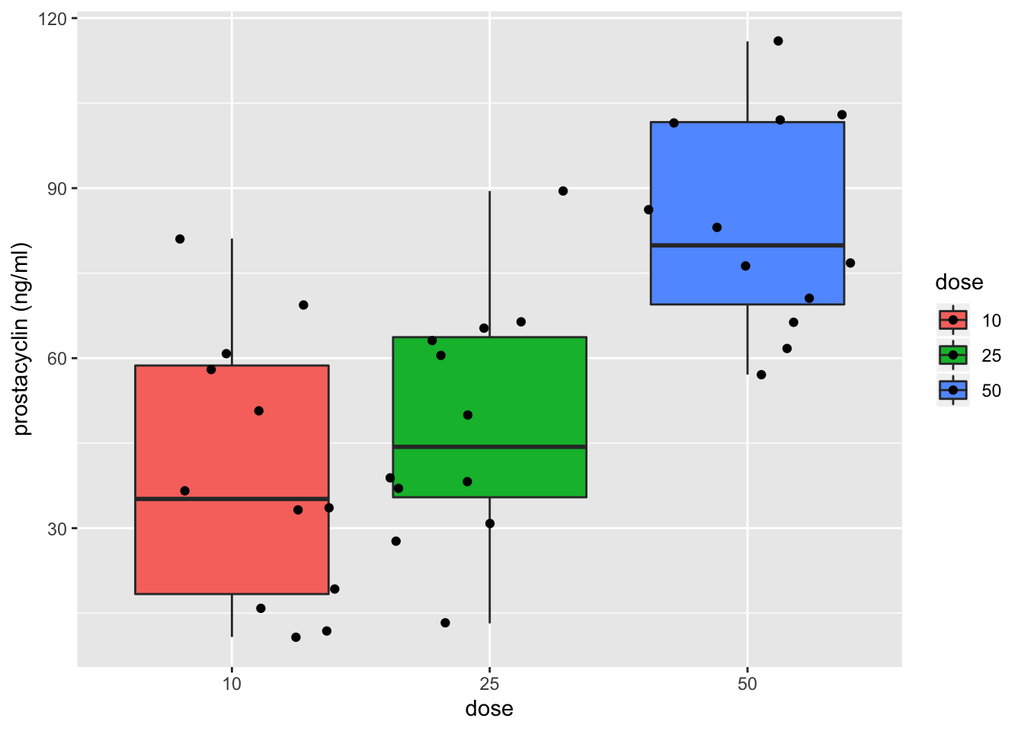

```r
prostacyclin %>%
  ggplot(aes(x=dose,y=prostac,fill=dose)) +
  geom_boxplot() +
  geom_point(position="jitter") +
  ylab("prostacyclin (ng/ml)")
```

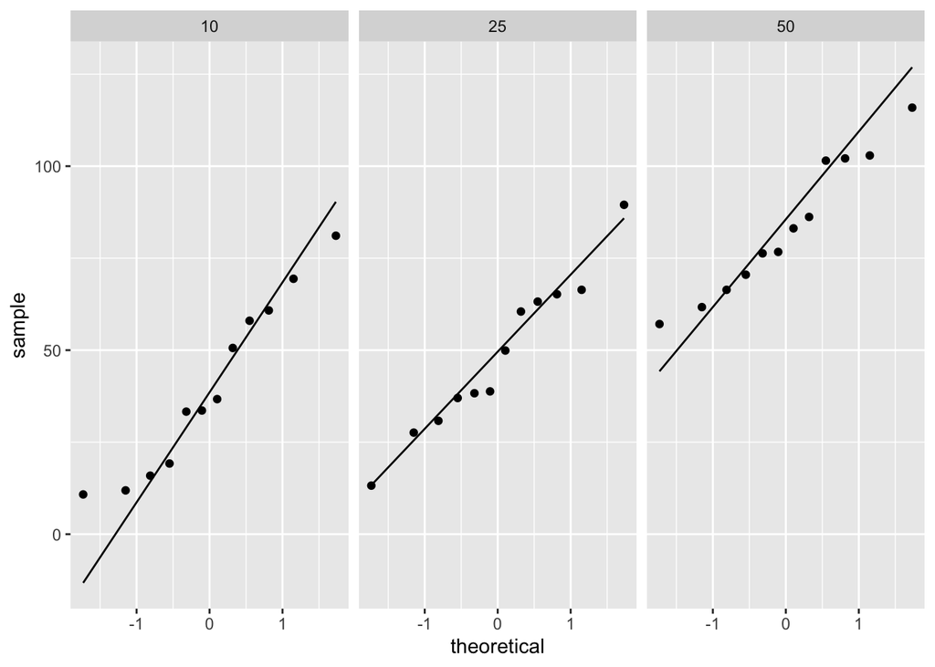

```r
prostacyclin %>%
  ggplot(aes(sample=prostac)) +
  geom_qq() +
  geom_qq_line() +
  facet_grid(~dose)
```

The data in the three groups are approximately Normally distributed with equal variance:
$$Y_i \vert \text{group j} \sim N(\mu_j,\sigma^2),$$
with $j= \text{1, 2, 3}$

## 1.2 Research question

Research question can translated in the following hypotheses

- $H_0$: the arachidonic acid concentration has no effect on the mean prostacyclin level in blood plasma in rats
  $$H_0:\mu_1=\mu_2 = \mu_3$$
- $H_1$: the arachidonic acid concentration has an effect on the mean prostacyclin level in blood plasma in rats, which implies that the at least two means are different.

In terms of the model parameters this becomes

$$H_0:\mu_1=\mu_2 = \mu_3$$
and
$$H_1: \exists\ j,k \in \{1,\ldots,g\} : \mu_j\neq\mu_k$$

We can assess this omnibus hypothesis using ANalysis of VAriance (ANOVA).

# 2 Analyse of Variance

```r
model1 <- lm(prostac~dose,data=prostacyclin)
anova(model1)
```

```
Analysis of Variance Table

Response: prostac
          Df Sum Sq Mean Sq F value    Pr(>F)
dose       2  12658  6329.0  13.944 4.081e-05 ***
Residuals 33  14979   453.9
---
Signif. codes:  0 '***' 0.001 '**' 0.01 '*' 0.05 '.' 0.1 ' ' 1
```

Based on the anova analysis we can reject the omnibus null hypothesis that there is no effect of the arachidonic acid treatment on the average prostacyclin concentration in rats. Next we continue to assess for which treatment groups the means are different using a posthoc analysis with the Tukey method to correct for multiple testing.

```r
#install.packages("multcomp")
library(multcomp)
model1.mcp<-glht(model1,linfct=mcp(dose="Tukey"))
summary(model1.mcp)
```

```
     Simultaneous Tests for General Linear Hypotheses

Multiple Comparisons of Means: Tukey Contrasts


Fit: lm(formula = prostac ~ dose, data = prostacyclin)

Linear Hypotheses:
             Estimate Std. Error t value Pr(>|t|)
25 - 10 == 0    8.258      8.698   0.949    0.613
50 - 10 == 0   43.258      8.698   4.974   <0.001 ***
50 - 25 == 0   35.000      8.698   4.024   <0.001 ***
---
Signif. codes:  0 '***' 0.001 '**' 0.01 '*' 0.05 '.' 0.1 ' ' 1
(Adjusted p values reported -- single-step method)
```

```r
confint(model1.mcp)
```

```
     Simultaneous Confidence Intervals

Multiple Comparisons of Means: Tukey Contrasts


Fit: lm(formula = prostac ~ dose, data = prostacyclin)

Quantile = 2.4544
95% family-wise confidence level


Linear Hypotheses:
             Estimate lwr      upr
25 - 10 == 0   8.2583 -13.0892  29.6059
50 - 10 == 0  43.2583  21.9108  64.6059
50 - 25 == 0  35.0000  13.6524  56.3476
```

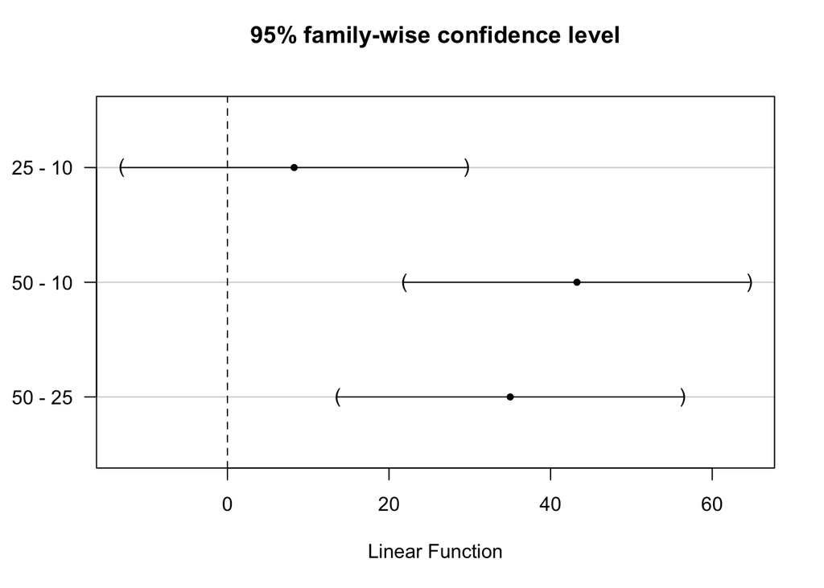

```r
plot(model1.mcp)
```

# 3 Conclusion

- There is an extreme significant effect of arachidonic acid on the average prostacyclin blood concentration in rats ($p<0.001$). The average prostacyclin concentration is higher in the high dose group than in the low and moderate dose group (both p-values are smaller than $p<0.001$).
- The average concentration in the high dose group is 43.3ng/ml (95% CI [21.9,64.6]ng/ml) and 35ng/ml (95% BI [13.7,56.3]ng/ml) higher than in the low and middle dose group, respectively.
- The difference in average prostacyclin concentration between the moderate and low dose group is not significant (p=0.61). (All p-values and confidence intervals for post-hoc tests are corrected for multiple testing using the Tukey method).